# Complex Regression

## Polynomial regression

In class, we took the log of price and the log of age in order to make the data look more linear. We fit a linear model to both the raw data and the log transformed data

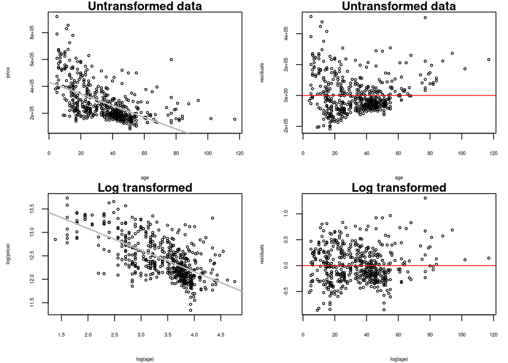

```r
reg_linear <- lm(price ~ age, data = housing_data)
reg_log <- lm(log(price) ~ log(age), data = housing_data)


par(mfrow = c(2,2), mar = c(4, 4, 1, 1))
plot(housing_data$age, housing_data$price, cex.lab = .5, cex.axis = .5,
     cex = .5, main = "Untransformed data", xlab = "age", ylab = "price")
abline(a = reg_linear$coef[1], b = reg_linear$coef[2], col = "gray", lwd = 2)
plot(housing_data$age, reg_linear$res, cex.lab = .5, cex.axis = .5,
     cex = .5, main = "Untransformed data", xlab = "age", ylab = "residuals")
abline(h = 0, col = "red")

plot(log(housing_data$age), log(housing_data$price), cex.lab = .5, cex.axis = .5,
     cex = .5, main = "Log transformed", xlab = "log(age)", ylab = "log(price)")
abline(a = reg_log$coef[1], b = reg_log$coef[2], col = "gray", lwd = 2)
plot(housing_data$age, reg_log$res, cex.lab = .5, cex.axis = .5,
     cex = .5, main = "Log transformed", xlab = "log(age)", ylab = "residuals")
abline(h = 0, col = "red")
```

We can see that the log transformed data looks much better, but as an alternative to fitting the transformed regression, we could also use polynomial regression instead of transforming the data. Let’s use the raw data, but also include a covariate of age squared.

```r
## R requires you to use I(age^2) instead of just including age^2
reg_quad1 <- lm(price ~ age + I(age^2), data = housing_data)
summary(reg_quad1)
```

```
##
## Call:
## lm(formula = price ~ age + I(age^2), data = housing_data)
##
## Residuals:
##     Min      1Q  Median      3Q     Max
## -280265  -55366  -21785   49671  432273
##
## Coefficients:
##              Estimate Std. Error t value Pr(>|t|)
## (Intercept) 552349.97   15860.35   34.83   <2e-16 ***
## age         -11922.03     795.81  -14.98   <2e-16 ***
## I(age^2)        93.34       9.26   10.08   <2e-16 ***
## ---
## Signif. codes:  0 '***' 0.001 '**' 0.01 '*' 0.05 '.' 0.1 ' ' 1
##
## Residual standard error: 105100 on 519 degrees of freedom
## Multiple R-squared:  0.4218, Adjusted R-squared:  0.4196
## F-statistic: 189.3 on 2 and 519 DF,  p-value: < 2.2e-16
```

The variables, age and age squared will be quite correlated, which as we will see on Wednesday can be a bad thing. So we typically will want to use a transformation of the polynomial covariates which are not as highly correlated. We will use the function which takes the covariate and the degree of the polynomial and return a set of covariates which act like age and age squared, but are not correlated. It’s also easier to type out instead of including a bunch of terms by hand. The coefficients aren’t directly interpretable since the covariates aren’t exactly age and age squared anymore, but we can see that they give the same fitted values as before.

```r
reg_quad2 <- lm(price ~ poly(age,2), data = housing_data)
summary(reg_quad2)
```

```
##
## Call:
## lm(formula = price ~ poly(age, 2), data = housing_data)
##
## Residuals:
##     Min      1Q  Median      3Q     Max
## -280265  -55366  -21785   49671  432273
##
## Coefficients:
##               Estimate Std. Error t value Pr(>|t|)
## (Intercept)     277894       4599   60.42   <2e-16 ***
## poly(age, 2)1 -1748855     105079  -16.64   <2e-16 ***
## poly(age, 2)2  1059186     105079   10.08   <2e-16 ***
## ---
## Signif. codes:  0 '***' 0.001 '**' 0.01 '*' 0.05 '.' 0.1 ' ' 1
##
## Residual standard error: 105100 on 519 degrees of freedom
## Multiple R-squared:  0.4218, Adjusted R-squared:  0.4196
## F-statistic: 189.3 on 2 and 519 DF,  p-value: < 2.2e-16
```

```r
sum(abs(reg_quad1$fitted.values - reg_quad2$fitted.values))
```

```
## [1] 1.193257e-08
```

We can’t directly compare the $R^2$ of log transformed model to the quadratic model since the dependent variables are different, but we can take the of the fitted values of the log model to bring the units back to dollars. We can then compare the RSS of the log model, the linear model and the model which include the quadratic term:

```r
sum((housing_data$price - exp(reg_log$fitted.values))^2)
```

```
## [1] 5.760537e+12
```

```r
sum((housing_data$price - reg_linear$fitted.values)^2)
```

```
## [1] 6.852419e+12
```

```r
sum((housing_data$price - reg_quad2$fitted.values)^2)
```

```
## [1] 5.730544e+12
```

We can also plot the predicted prices for each model:

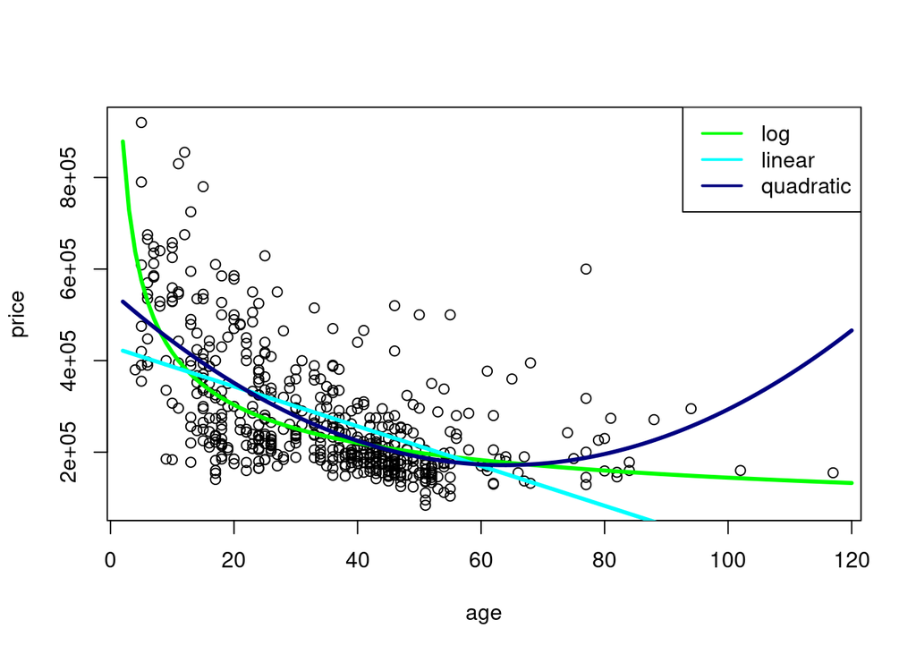

```r
plot(housing_data$age, housing_data$price, xlab = "age", ylab = "price")
lines(2:120, exp(predict(reg_log, data.frame(age = 2:120))),
      col = "green", lwd = 3)
lines(2:120, predict(reg_linear, data.frame(age = 2:120)),
      col = "cyan", lwd = 3)
lines(2:120, predict(reg_quad1, data.frame(age = 2:120)),
      col = "navy", lwd = 3)
legend("topright", col = c("green", "cyan", "navy"),
       legend = c("log", "linear", "quadratic"), lwd = 2)
```